# TO414 Project 3: Spotify

Ankita Mohapatra, Jonathan Demeter, Charlie Logan, Nikita Mehendale, Srishti Senthil

4/23/2021

# Objective

Intended Audience: Music producers, artists, advertisers Overarching Objective: Our goal is to better understand music consumption patterns and trends among popular songs through the years. Underlying Objective 1 (for music producers and artists): Recognize which aspects correlate to popularity and creating mega hits Underlying Objective 2 (for Spotify): Help create automatic classification in recommendation algorithms and creating playlists (based on decade for example). Underlying Objective 3 (for advertisers): Recognize what kind of music is most popular for advertisers to target intended audiences.

1. Descriptive Analytics: How do audio features differ across decades? How do audio features differ by popularity?
2. Predictive Analytics: Can we predict danceability? Can we predict popularity? Can we predict if a song is from a particular decade? Can we find patterns among a single artist’s most popular songs?

Finally, we will identify several applications for the insights presented in this analysis.

## Load Spotify Data

```r
#set random seed
set.seed(1234)
#load csvs
spotify <- read.csv("data.csv")
audio_features <- read.csv("tracks.csv")
```

## Glossary of Variables

The spotify and audio features datasets contain a combination of objective and subjective musical attributes.

Objective attributes of a musical track which are available in these datasets include:

- `key` the major key of the track, where each number corresponds to a unique key
- `loudness` average volume of the track in decibels
- `mode` major or minor classification
- `duration` time duration of the track in milliseconds
- `release_year` of the album containing this track
- `tempo` of the track in beats per minute (BPM)

Subjective attributes of a musical track which are available in these datasets, calculated in function of other measured properties, include:

- `danceability` the track’s suitability for dancing, on a 0-1 scale
- `energy` how energetic the track is, on a 0-1 scale
- `valence` how positive/cheerful the music is, on a 0-1 scale
- `acousticness` how acoustic the song is, on a 0-1 scale

Finally, there are some variables which have used a [likely subjective] algorithm to describe objective attributes, resulting in a debatable classification:

- `liveness` presence of audience, audible in the track, on a 0-1 scale
- `instrumentalness` ratio of instrumental sounds throughout track, on a 0-1 scale
- `speechiness` ratio of spoken words
- `time_signature` predicted time signature of the track

## Load Libraries

```r
#load libraries
packages <- c("dplyr", "class", "caret", "gmodels", "C50", "patchwork")
lapply(packages, require, character.only = TRUE)
```

```
## [[1]]
## [1] TRUE
##
## [[2]]
## [1] TRUE
##
## [[3]]
## [1] TRUE
##
## [[4]]
## [1] TRUE
##
## [[5]]
## [1] TRUE
##
## [[6]]
## [1] TRUE
```

## Data Manipulation

Main Data

```r
spotify <- subset(spotify, select = -c(id, name, release_date))
spotify$artists <- as.factor(spotify$artists)
spotify$key <- as.factor(spotify$key)

# Cut year into bins by decade
spotify$decades <- cut(spotify$year, breaks = c(0,1929, 1939, 1949, 1959, 1969, 1979, 1989, 1999, 2009, 2019, Inf), labels = c("20s", "30s", "40s", "50s", "60s", "70s", "80s", "90s", "2000s", "2010s", "2020s"))


# Classify popularity into bins by 75% and 90% percentiles
popularity_threshold <- 42
quantile(spotify$popularity, probs=seq(.1, .9, by = .1))
```

```
## 10% 20% 30% 40% 50% 60% 70% 80% 90%
##   0   0   6  17  25  32  39  46  56
```

```r
spotify$hit_class <- ifelse(spotify$popularity >= 56, "mega-hit", ifelse(spotify$popularity > popularity_threshold, "hit", "not hit"))
spotify$hit_class <- as.factor(spotify$hit_class)
# true or false if top 10% or not
spotify$binary_hit_class <- ifelse(spotify$hit_class == "mega-hit", 1, 0)
spotify$binary_hit_class <- as.factor(spotify$binary_hit_class)
table(spotify$hit_class)
```

```
##
##      hit mega-hit  not hit
##    24325    18590   131474
```

## Test & Train

Split spotify set into test and train sets to be used throughout

```r
test_set <- sample(1:nrow(spotify), 30000)
spotify_train <- spotify[-test_set, ]
spotify_test <- spotify[test_set, ]
```

# General Music Attributes

## By Decade

First, we wanted to see what kind of music is most popular on spotify.

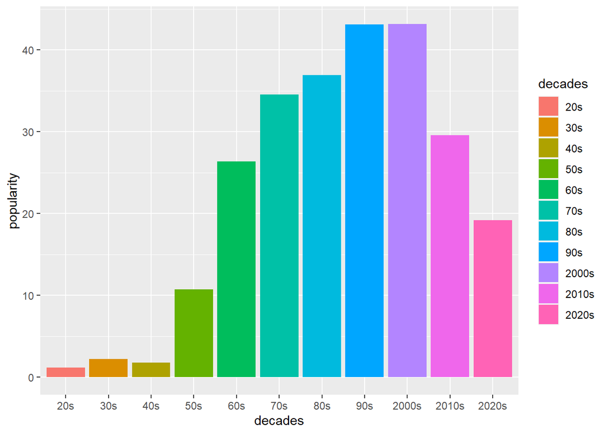

```r
ggplot(spotify, aes(x = decades, y = popularity, fill=decades)) +
  geom_bar(stat = "summary", fun = "mean")
```

The most listened to songs are from the 90s and 2000s. This makes sense since that is the generation that started being comfortable with new technology, and also that music has been on the platform longer than the music from 2010s or 2020s. We predict that people that listen to older music might listen to it in different forms (i.e. CDs, records, tapes, etc.). Next, we wanted to look at the different audio features over the decades.

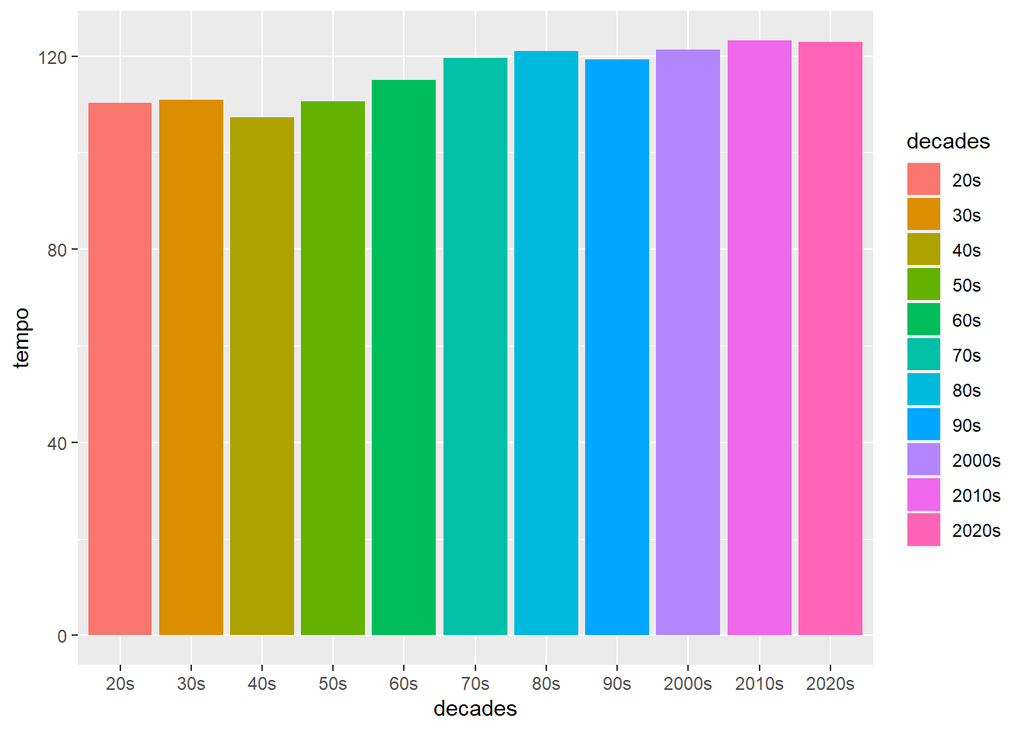

```r
ggplot(spotify, aes(x = decades, y = tempo, fill=decades)) +
  geom_bar(stat = "summary", fun = "mean")
```

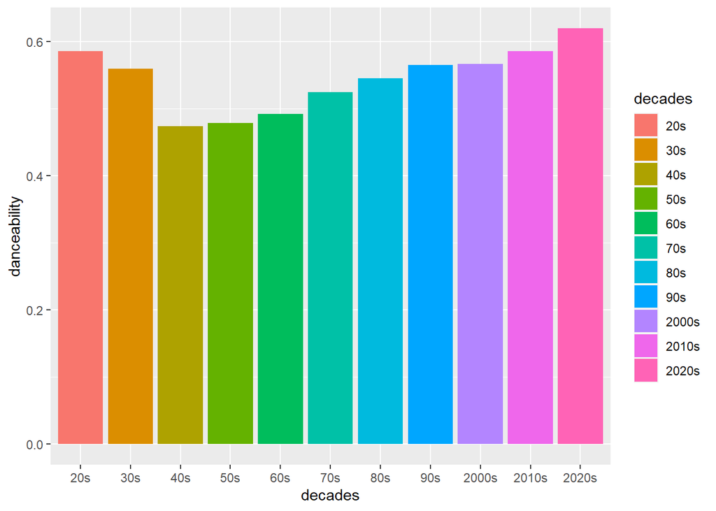

```r
ggplot(spotify, aes(x = decades, y = danceability, fill=decades)) +
  geom_bar(stat = "summary", fun = "mean")
```

The previous graphs show a trend where the audio features start out at a certain point in the 20s and then drop down in the 30s-50s, and then increase rather steadily. Our team theorized that this may be due to the Great Depression and prohibition happening at the beginning of the 30s that caused this turn in culture.

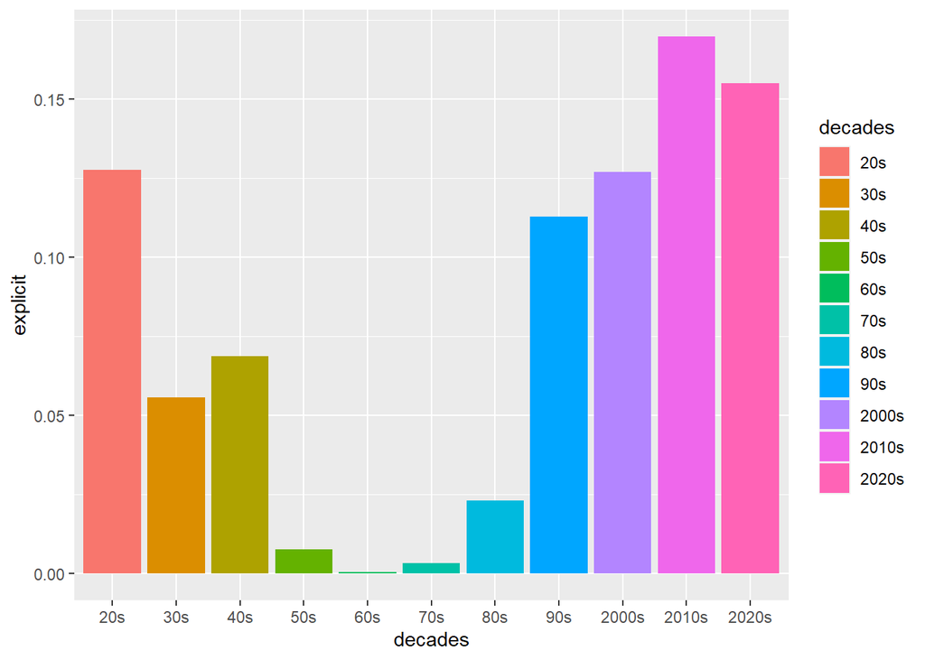

```r
ggplot(spotify, aes(x = decades, y = explicit, fill=decades)) +
  geom_bar(stat = "summary", fun = "mean")
```

We were surprised at the graph showing the trends in explicitness because they varied so much and the average seems to be really high for the 20s. We think this is because there is a much smaller number of songs from the 20s in this data set. It dropped off to almost 0 in the 60s and 70s, and then shot up with the prevalence of rock and hip hop.

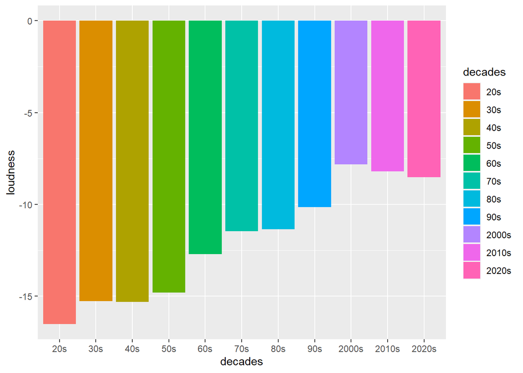

```r
ggplot(spotify, aes(x = decades, y = loudness, fill=decades)) +
  geom_bar(stat = "summary", fun = "mean")
```

Finally, we looked at the loudness. It is expected to see that loudness increases as time goes on and technology improves, but it was interesting that in 2010s and 2020s it has been getting a little quieter. This may be due to increased health concerns. For example, iPhones will warn you if you are listening to music too loud for too long, and has settings that allow you to limit your volume when you are wearing headphones so you don’t damage your ears.

## By Popularity

Next, we wanted to see how the audio features differ across our three classes of popularity: not a hit, hit, and mega hit.

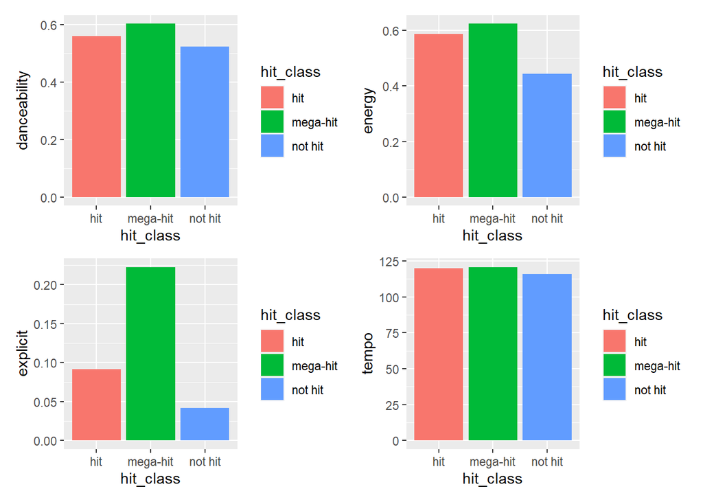

```r
ggplot(spotify, aes(x = hit_class, y = danceability, fill=hit_class)) +
  geom_bar(stat = "summary", fun = "mean")+ggplot(spotify, aes(x = hit_class, y = energy, fill=hit_class)) +
  geom_bar(stat = "summary", fun = "mean")+ggplot(spotify, aes(x = hit_class, y = explicit, fill=hit_class)) +
  geom_bar(stat = "summary", fun = "mean")+ggplot(spotify, aes(x = hit_class, y = tempo, fill=hit_class)) +
  geom_bar(stat = "summary", fun = "mean")
```

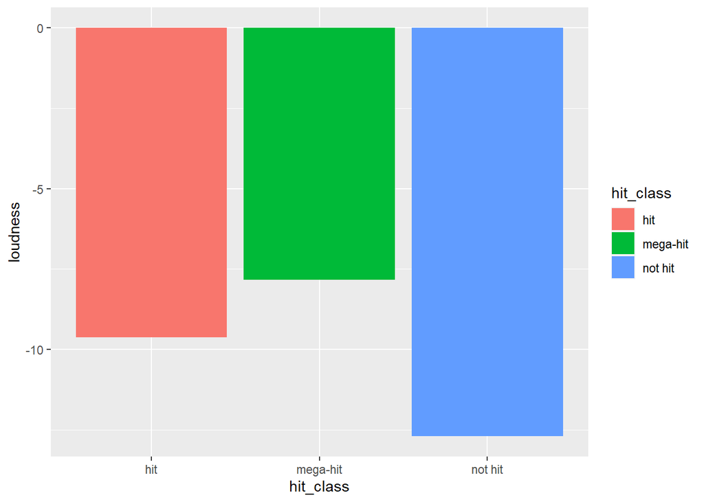

```r
ggplot(spotify, aes(x = hit_class, y = loudness, fill=hit_class)) +
  geom_bar(stat = "summary", fun = "mean")
```

In the previous graphs, we see that mega hit has the highest mean for danceability, energy, explicitness, tempo, and loudness. While there are other factors that determine popularity, such as artist recognition, we can see that high values in these factors is correlated with popularity.

In the following graphs, we see a similar trend but in the opposite direction. Mega hits have the lowest averages for acousticness, instrumentalness, liveness, mode, and valence.

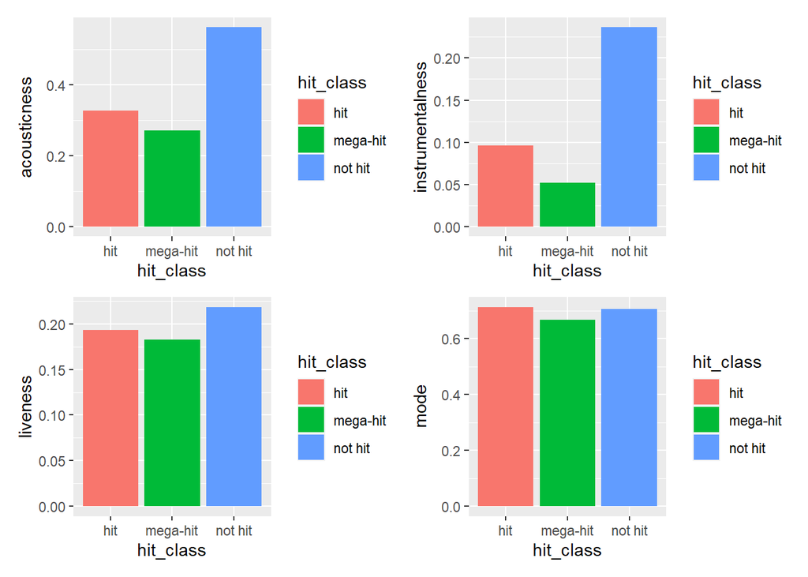

```r
ggplot(spotify, aes(x = hit_class, y = acousticness, fill=hit_class)) + geom_bar(stat = "summary", fun = "mean")+ ggplot(spotify, aes(x = hit_class, y = instrumentalness, fill=hit_class)) +
  geom_bar(stat = "summary", fun = "mean")+ggplot(spotify, aes(x = hit_class, y = liveness, fill=hit_class)) +
  geom_bar(stat = "summary", fun = "mean")+ggplot(spotify, aes(x = hit_class, y = mode, fill=hit_class)) +
  geom_bar(stat = "summary", fun = "mean")
```

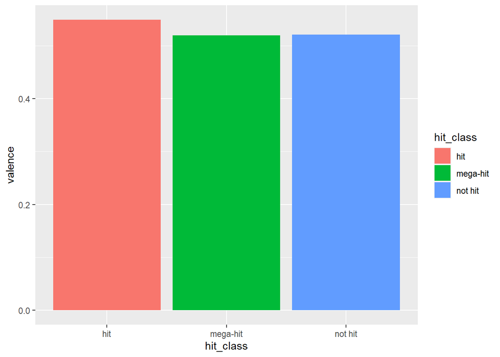

```r
ggplot(spotify, aes(x = hit_class, y = valence, fill=hit_class)) +
  geom_bar(stat = "summary", fun = "mean")
```

Finally, we also wanted to look at the artists with the most songs in the dataset.

```r
sort(table(spotify$artists), decreasing = TRUE)[1:20]
```

[output not shown]

# Decade Prediction

Music is constantly changing forms and styles throughout the years, and often these changes mirror social and cultural changes within a society. In this section we will explore whether the decade a song was created can be accurately predicted by the style and form of the song. This can help us understand the differentiating factors and the relationships between musical decades. This can be used by recommendation algorithms on Youtube, Spotify, or other music streaming programs. It can be used to introduce listeners to new music from other time periods that may be similar in sounds or feeling to what the user already listens to. Many times music listerners just listen to their contemporaries, but there is plenty of music to explore from the past century.

## Is the song from the 80s?

```r
eighties_train <- subset(spotify_train, select = -c(artists, year, hit_class))
eighties_test <- subset(spotify_test, select = -c(artists, year, hit_class))
eighties_train$eighties <- ifelse(eighties_train$decades == "80s", 1, 0)
eighties_test$eighties <- ifelse(eighties_test$decades == "80s", 1, 0)
```

First We prepared the train and test data for the 80s prediction test. We removed certain columns from the data set that were irrelevant or dependent on a songs release decade such as artists, year, and hit_class. We then added a boolean column to the data sets indicating whether the song was released in the 1980s or not.

```r
eighties_log <- glm(eighties ~ acousticness + danceability + duration_ms + energy + explicit +
                      instrumentalness + liveness + loudness + mode +
                      speechiness + tempo + key + instrumentalness*danceability +
                      duration_ms*acousticness + duration_ms*valence + duration_ms*valence + danceability*instrumentalness,
                    data = eighties_train, family = "binomial")
summary(eighties_log)
```

```
##
## Call:
## glm(formula = eighties ~ acousticness + danceability + duration_ms +
##     energy + explicit + instrumentalness + liveness + loudness +
##     mode + speechiness + tempo + key + instrumentalness * danceability +
##     duration_ms * acousticness + duration_ms * valence + duration_ms *
##     valence + danceability * instrumentalness, family = "binomial",
##     data = eighties_train)
##
## Deviance Residuals:
##     Min       1Q   Median       3Q      Max
## -3.8626  -0.5389  -0.3535  -0.2155   3.7083
##
## Coefficients:
##                                 Estimate Std. Error z value Pr(>|z|)
## (Intercept)                   -4.586e+00  1.066e-01 -43.003  < 2e-16 ***
## acousticness                  -1.794e+00  5.741e-02 -31.258  < 2e-16 ***
## danceability                   1.072e+00  7.382e-02  14.516  < 2e-16 ***
## duration_ms                   -1.681e-06  1.781e-07  -9.434  < 2e-16 ***
## energy                         2.675e+00  7.088e-02  37.744  < 2e-16 ***
## explicit                      -1.108e+00  5.651e-02 -19.612  < 2e-16 ***
## instrumentalness               1.883e-01  8.611e-02   2.187 0.028739 *
## liveness                      -3.697e-01  5.029e-02  -7.351 1.97e-13 ***
## loudness                      -1.757e-01  2.787e-03 -63.058  < 2e-16 ***
## mode                           9.618e-02  2.012e-02   4.779 1.76e-06 ***
## speechiness                   -3.940e+00  1.228e-01 -32.075  < 2e-16 ***
## tempo                          2.153e-03  3.229e-04   6.667 2.62e-11 ***
## key1                          -3.883e-01  4.341e-02  -8.945  < 2e-16 ***
## key2                           9.458e-03  3.436e-02   0.275 0.783115
## key3                          -2.162e-01  5.627e-02  -3.842 0.000122 ***
## key4                           1.138e-01  3.764e-02   3.023 0.002506 **
## key5                          -2.031e-01  3.899e-02  -5.210 1.89e-07 ***
## key6                          -1.968e-01  4.668e-02  -4.215 2.50e-05 ***
## key7                          -6.404e-02  3.404e-02  -1.881 0.059955 .
## key8                          -2.634e-01  4.572e-02  -5.762 8.33e-09 ***
## key9                           6.854e-02  3.427e-02   2.000 0.045502 *
## key10                         -2.486e-01  4.391e-02  -5.662 1.50e-08 ***
## key11                          4.172e-02  4.126e-02   1.011 0.311935
## valence                       -1.171e+00  7.899e-02 -14.828  < 2e-16 ***
## danceability:instrumentalness -3.340e+00  1.705e-01 -19.587  < 2e-16 ***
## acousticness:duration_ms       1.126e-06  1.698e-07   6.629 3.37e-11 ***
## duration_ms:valence            4.806e-06  2.807e-07  17.121  < 2e-16 ***
## ---
## Signif. codes:  0 '***' 0.001 '**' 0.01 '*' 0.05 '.' 0.1 ' ' 1
##
## (Dispersion parameter for binomial family taken to be 1)
##
##     Null deviance: 103241  on 144388  degrees of freedom
## Residual deviance:  89415  on 144362  degrees of freedom
## AIC: 89469
##
## Number of Fisher Scoring iterations: 6
```

```r
eighties_pred_log <- predict(eighties_log, eighties_test, type = "response")
eighties_pred_log <- ifelse(eighties_pred_log > .23, 1, 0)
summary(eighties_pred_log)
```

```
##    Min. 1st Qu.  Median    Mean 3rd Qu.    Max.
##  0.0000  0.0000  0.0000  0.1344  0.0000  1.0000
```

```r
confusionMatrix(as.factor(eighties_pred_log), as.factor(eighties_test$eighties))
```

```
## Confusion Matrix and Statistics
##
##           Reference
## Prediction     0     1
##          0 23862  2105
##          1  2716  1317
##
##                Accuracy : 0.8393
##                  95% CI : (0.8351, 0.8434)
##     No Information Rate : 0.8859
##     P-Value [Acc > NIR] : 1
##
##                   Kappa : 0.2623
##
##  Mcnemar's Test P-Value : <2e-16
##
##             Sensitivity : 0.8978
##             Specificity : 0.3849
##          Pos Pred Value : 0.9189
##          Neg Pred Value : 0.3266
##              Prevalence : 0.8859
##          Detection Rate : 0.7954
##    Detection Prevalence : 0.8656
##       Balanced Accuracy : 0.6413
##
##        'Positive' Class : 0
##
```

First we constructed a Logistic Regression to predict whether a song was released in the 80s. The regression resulted in an accuracy of 83.93% and a Kappa value of .2623. The model has many false negatives and false positives and doesn’t seem to do a great job distinguishing between 80s music and other decades. Our model suggests that 80s songs have less acousticness, more instrumentals, are more danceable, have high energy, and tend to have a faster tempo. This makes sense considering 80s music was the decade electronic dance music was introduced.

```r
error_costs = matrix(c(0, 1, 2, 0), nrow = 2)
eighties_dtm <- C5.0(as.factor(eighties) ~ acousticness + danceability + duration_ms + energy + explicit +
                      instrumentalness + liveness + loudness + mode +
                      speechiness + tempo + key, data = eighties_train, costs = error_costs)
eighties_pred_dt <- predict(eighties_dtm, eighties_test)
confusionMatrix(as.factor(eighties_pred_dt), as.factor(eighties_test$eighties))
```

```
## Confusion Matrix and Statistics
##
##           Reference
## Prediction     0     1
##          0 24578  2294
##          1  2000  1128
##
##                Accuracy : 0.8569
##                  95% CI : (0.8529, 0.8608)
##     No Information Rate : 0.8859
##     P-Value [Acc > NIR] : 1
##
##                   Kappa : 0.2643
##
##  Mcnemar's Test P-Value : 7.774e-06
##
##             Sensitivity : 0.9247
##             Specificity : 0.3296
##          Pos Pred Value : 0.9146
##          Neg Pred Value : 0.3606
##              Prevalence : 0.8859
##          Detection Rate : 0.8193
##    Detection Prevalence : 0.8957
##       Balanced Accuracy : 0.6272
##
##        'Positive' Class : 0
##
```

Our decision tree model performed slightly better than our logistc regression model. The decision tree has an accuracy of 85.69% and a Kappa value of .2643. Because there are many more non 80s songs than 80s, I added a cost matrix to encourage the decision tree to minimize false negative responses. Although this model did better, it loses the intepratability that the logistic regression models has. Because of this I think the logistic regression model is more valuable for our purposes.

## Classifying Songs into Every Decade

```r
decade_dtm <- C5.0(decades ~ acousticness + danceability + duration_ms + energy + explicit +
                      instrumentalness + liveness + loudness +
                      speechiness + tempo + valence, data = spotify_train)

decades_pred <- predict(decade_dtm, spotify_test, type = "class")
summary(decades_pred)
```

```
##   20s   30s   40s   50s   60s   70s   80s   90s 2000s 2010s 2020s
##  1000  1918  3022  3446  3432  3607  3303  3211  1979  4170   912
```

```r
confusionMatrix(decades_pred, as.factor(spotify_test$decades))
```

```
## Confusion Matrix and Statistics
##
##           Reference
## Prediction  20s  30s  40s  50s  60s  70s  80s  90s 2000s 2010s 2020s
##      20s    466  110  164  124   43   22   14   22     8    23     4
##      30s    109  846  351  298  101   48   56   34    21    42    12
##      40s    159  420 1173  598  221  121   99   95    50    66    20
##      50s    114  255  519 1121  574  240  178  203    94   122    26
##      60s     32   88  181  579 1088  496  285  306   145   187    45
##      70s      9   44   89  236  517 1049  639  493   224   262    45
##      80s     13   32   75  131  271  604 1023  547   230   324    53
##      90s      9   24   61  153  235  423  536  917   390   395    68
##      2000s    2    9   24   63  102  167  204  349   513   471    75
##      2010s   27   37   56  153  202  283  344  436   538  1774   320
##      2020s    6    6   11   19   18   32   44   43    68   210   455
##
## Overall Statistics
##
##                Accuracy : 0.3475
##                  95% CI : (0.3421, 0.3529)
##     No Information Rate : 0.1292
##     P-Value [Acc > NIR] : < 2.2e-16
##
##                   Kappa : 0.2724
##
##  Mcnemar's Test P-Value : < 2.2e-16
##
## Statistics by Class:
##
##                      Class: 20s Class: 30s Class: 40s Class: 50s Class: 60s
## Sensitivity             0.49260    0.45216    0.43380    0.32259    0.32266
## Specificity             0.98162    0.96189    0.93226    0.91235    0.91197
## Pos Pred Value          0.46600    0.44108    0.38815    0.32530    0.31702
## Neg Pred Value          0.98345    0.96350    0.94325    0.91135    0.91403
## Prevalence              0.03153    0.06237    0.09013    0.11583    0.11240
## Detection Rate          0.01553    0.02820    0.03910    0.03737    0.03627
## Detection Prevalence    0.03333    0.06393    0.10073    0.11487    0.11440
## Balanced Accuracy       0.73711    0.70703    0.68303    0.61747    0.61731
##                      Class: 70s Class: 80s Class: 90s Class: 2000s Class: 2010s
## Sensitivity             0.30100     0.2989    0.26618      0.22490      0.45769
## Specificity             0.90353     0.9142    0.91361      0.94711      0.90828
## Pos Pred Value          0.29082     0.3097    0.28558      0.25922      0.42542
## Neg Pred Value          0.90770     0.9101    0.90563      0.93690      0.91862
## Prevalence              0.11617     0.1141    0.11483      0.07603      0.12920
## Detection Rate          0.03497     0.0341    0.03057      0.01710      0.05913
## Detection Prevalence    0.12023     0.1101    0.10703      0.06597      0.13900
## Balanced Accuracy       0.60227     0.6066    0.58990      0.58601      0.68299
##                      Class: 2020s
## Sensitivity               0.40516
## Specificity               0.98417
## Pos Pred Value            0.49890
## Neg Pred Value            0.97704
## Prevalence                0.03743
## Detection Rate            0.01517
## Detection Prevalence      0.03040
## Balanced Accuracy         0.69467
```

The decision tree performed decently well considering how many classes there are and the difficulties in predicting a song’s release decade. The model has an accuracy of 34.75% and a Kappa value of .2724. Its interesting to look along the diagonal in the confusion matrix and see that for any given decade of music, the decision tree model predicted the correct decade more than any other individual decade except for 2000s music. This indicated that the model is catching onto the trends and differences in music by decade.

It’s also interesting to look at how the decision tree is more likely to mistake a song’s decade with an adjacent decade than one further away in time.

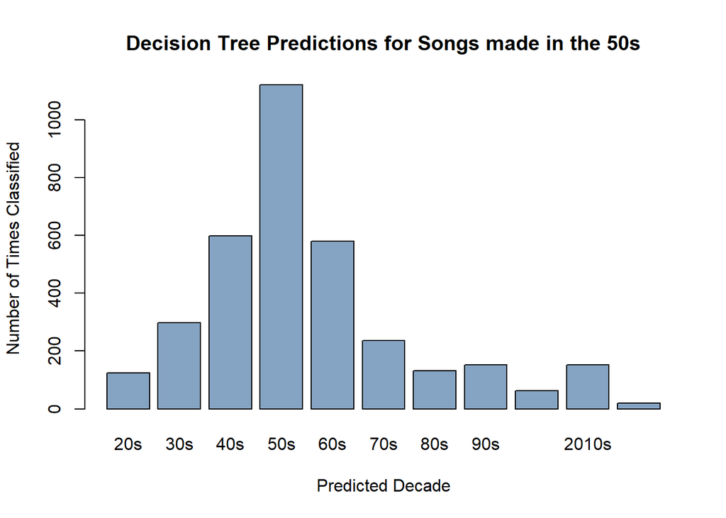

```r
fifties_preds <- c(124, 298, 598, 1121, 579, 236, 131, 153, 63, 153, 19)

barplot(fifties_preds, main="Decision Tree Predictions for Songs made in the 50s",
        xlab="Predicted Decade", ylab="Number of Times Classified", names.arg=c("20s", "30s", "40s", "50s", "60s", "70s", "80s", "90s", "2000s", "2010s", "2020s"), col=rgb(.2, .4, .6, .6))
```

For example, for all 50s songs, our model accurately predicted 1121 of them. One decade away from the 50s is the 40s and 60s, which recieved 598 and 579 predictions respectively. The general trend is the further away in time a decade is from a songs true decade, the less likely our model is to incorrectly classify it into that decade. This relates back to my comments above about change in music not being discrete but continuous. Songs from the 50s and 60s will sound more alike than songs from the 50s and 90s, and our model is picking up on that. There are many similarities between the musical decades, and music waves don’t necessarily line up with the end of a decade and the start of a new one. That’s why its interesting to see and interpret our models results in a bar graph of all classifications rather than just as a binary correct or incorrect prediction. Suprisingly, our plot above shows a small bump in 2010s. This could indicate that 2010 music has some similarities to 1950s music, or at least more similarities than the 2000s and 2020s do to the 1950s. This is an example where Spotify can recommend some 50s music to someone who listens to a lot of music from the 2010s.

We can look at songs released in the 2000s and see how the decision tree struggled with predicting 2000s songs accurately. The model often mistook 2000s songs for other decades’ songs. This leads me to believe that the 2000s didn’t have a defining sound to their music and was a combination of many other decades’ sounds.

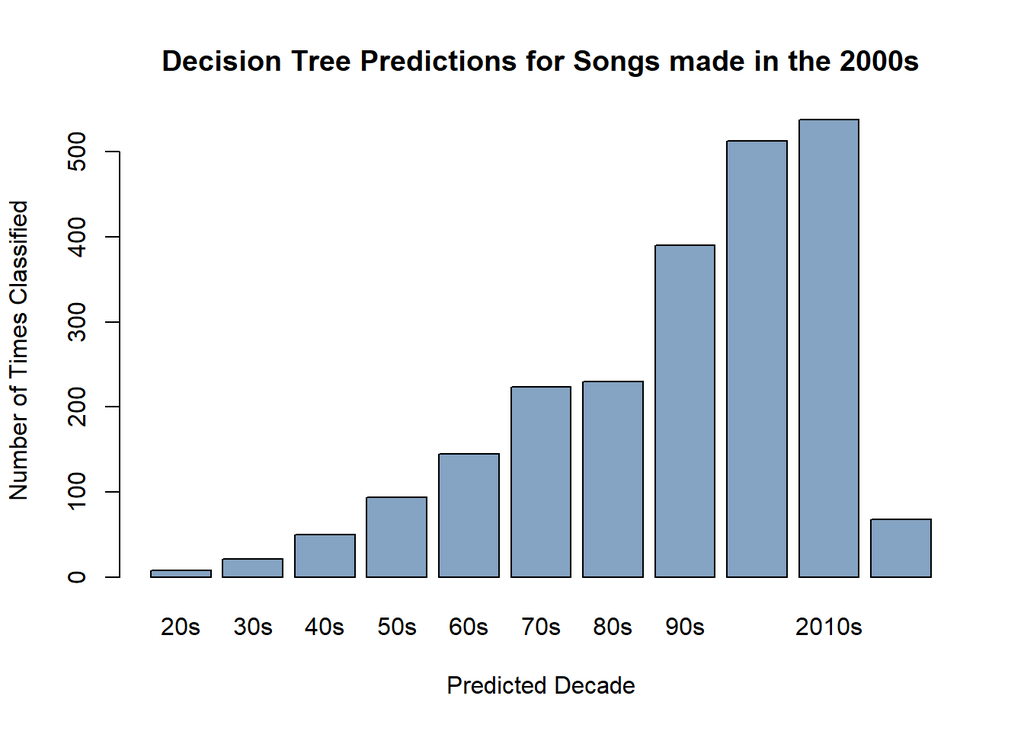

```r
two_thous_preds <- c(8, 21, 50, 94, 145, 224, 230, 390, 513, 538, 68)

barplot(two_thous_preds, main="Decision Tree Predictions for Songs made in the 2000s",
        xlab="Predicted Decade",  ylab="Number of Times Classified", names.arg=c("20s", "30s", "40s", "50s", "60s", "70s", "80s", "90s", "2000s", "2010s", "2020s"), col=rgb(.2, .4, .6, .6))
```

A possible prediction is that the 2000s was a transitional period for music. On the way out was 90s music and on the way in was 2010’s music style. This can be substantiated by the high classifications of 2000s music into the 90s and 2010s. In fact, for all 2000s music, 538 songs were wrongly predicted to be from the 2010s and only 513 songs were accurately predicted as the 2000s.This sort of information can be valuable to a recommendation system because it suggests that someone who listens to 2000s music doesn’t have a specifically unique taste and might like variety in their music choices. This can be compared to someone who listens to 50s music, which our model suggests is more differentiated from other decades’ music, and might not like as much variety in their music.

# Danceability Prediction

**What is danceability?** Spotify defines danceability as follows: ``Danceability describes how suitable a track is for dancing based on a combination of musical elements including tempo, rhythm stability, beat strength, and overall regularity. A value of 0.0 is least danceable and 1.0 is most danceable.’’

## Description of Data and Procedure

In this analysis we will run linear running regression models on the audio features train data to predict to what extent the danceability algorithm incorporates various elements of musicality, including those self-reported in Spotify’s danceability definition, as well as other objective and subjective attributes available to our analysis.

### Limitations

It is important to note that there is an inherent limitation in predictive power when subjective variables are used due to bias and reliance on imperfect algorithms. That is, there is no human music assessor who is individually ranking Spotify’s wealth of streamable music for perceived `danceability`. Rather, `danceability` as a variable in the Spotify API represents Spotify developers’ algorithm’s best attempt at predicting danceability based on the criteria which they consider most important to making music suitable for dancing, such as tempo and beat regularity. The algorithm does not necessarily output the same `danceability` rating had the developers individually listened to the track and assigned it a danceability score. Therefore, while the concept of measuring subjective attributes such as danceability is intellectually attractive for use cases such as allowing users to filter music, improving recommendation algorithms, and pre-populating automated playlists, these measurements are imperfect. For instance [this Quora post](https://www.quora.com/How-does-Spotify-calculate-the-danceability-of-a-song) written by pianist Juan Maria Solare links to [this dreamy minimal piano solo](https://play.spotify.com/track/2I97NDZU4o16A1nP9zgMah) which may not be easily danceable for most audiences, yet is ranked by Spotify as a 6.7/10 for `danceability`, sitting at the 71st percentile within the `danceability` distribution:

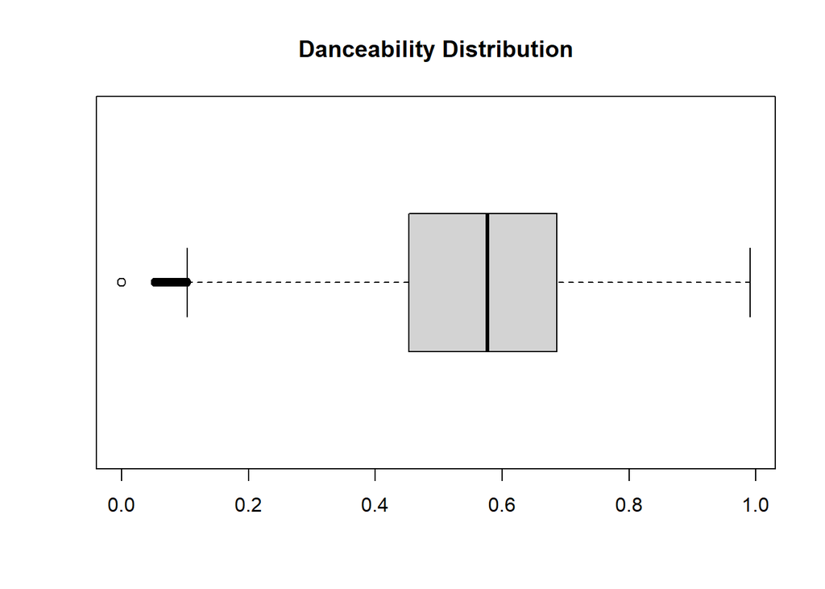

```r
#Look at danceability distribution in `audio_features`
boxplot(audio_features$danceability, horizontal=T, main="Danceability Distribution")
```

```r
quantile(audio_features$danceability, probs = c(.7,.71,.72,.75))   #Score of 6.7 falls at ~71st percentile
```

```
##   70%   71%   72%   75%
## 0.663 0.668 0.672 0.686
```

## Audio Features Data Preparation

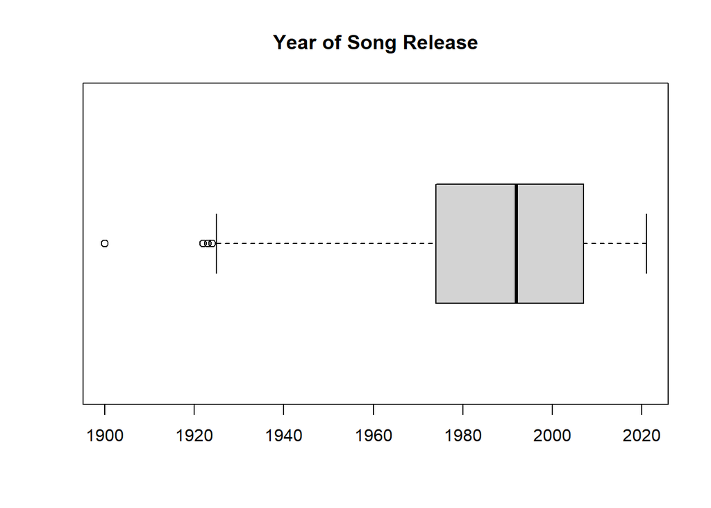

```r
audio_features$release_year <- substr(audio_features$release_date,1,4)
audio_features$release_year <- as.numeric(audio_features$release_year)
audio_features$key <- as.factor(audio_features$key)
audio_features$mode <- as.factor(audio_features$mode)
boxplot(audio_features$release_year, horizontal = T, main = "Year of Song Release")
```

```r
audio_features <- subset(audio_features, select = -c(id, name, popularity, artists, id_artists, release_date))
audio_features <- audio_features %>%
  select(danceability,everything())   #bring `danceability` to first column
```

We remove music longer than 10 minutes from the data, to account for outliers.

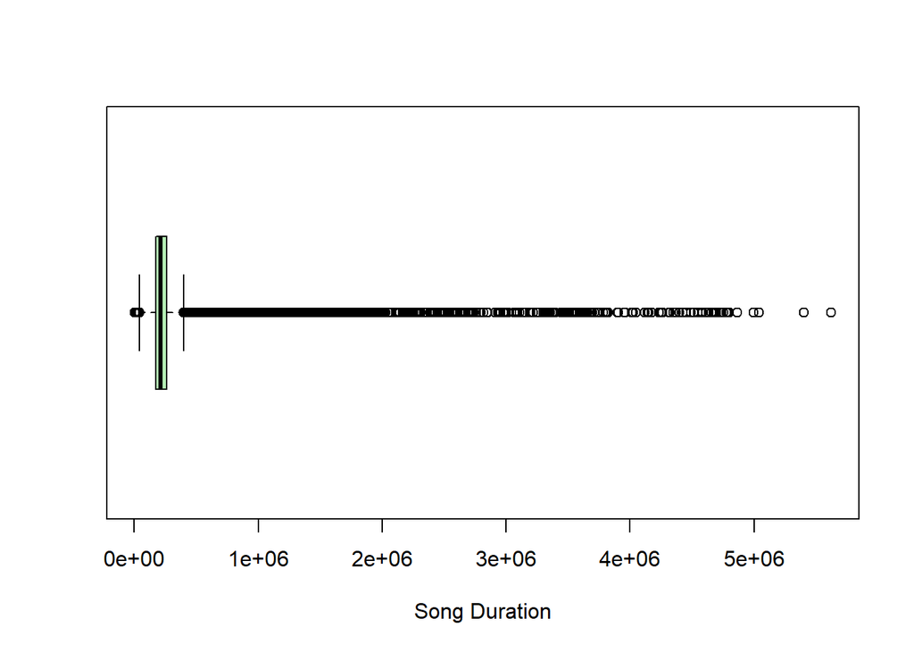

```r
boxplot(audio_features$duration_ms, horizontal = T, col = "darkseagreen2", xlab = "Song Duration") #Extremely right-skewed, many large outliers
```

```r
summary(audio_features$duration_ms) #Summary shows the desired distribution, but boxplot does not
```

```
##    Min. 1st Qu.  Median    Mean 3rd Qu.    Max.
##    3344  175093  214893  230051  263867 5621218
```

```r
quantile(audio_features$duration_ms, probs=seq(.9, 1, by = .005))
```

```
##       90%     90.5%       91%     91.5%       92%     92.5%       93%     93.5%
##  323573.0  327333.0  331454.8  335867.0  340787.0  345840.0  351582.0  357815.7
##       94%     94.5%       95%     95.5%       96%     96.5%       97%     97.5%
##  365133.0  373373.0  382333.0  392567.6  404950.0  419041.5  435558.8  457756.9
##       98%     98.5%       99%     99.5%      100%
##  486867.0  528733.0  598027.9  779283.2 5621218.0
```

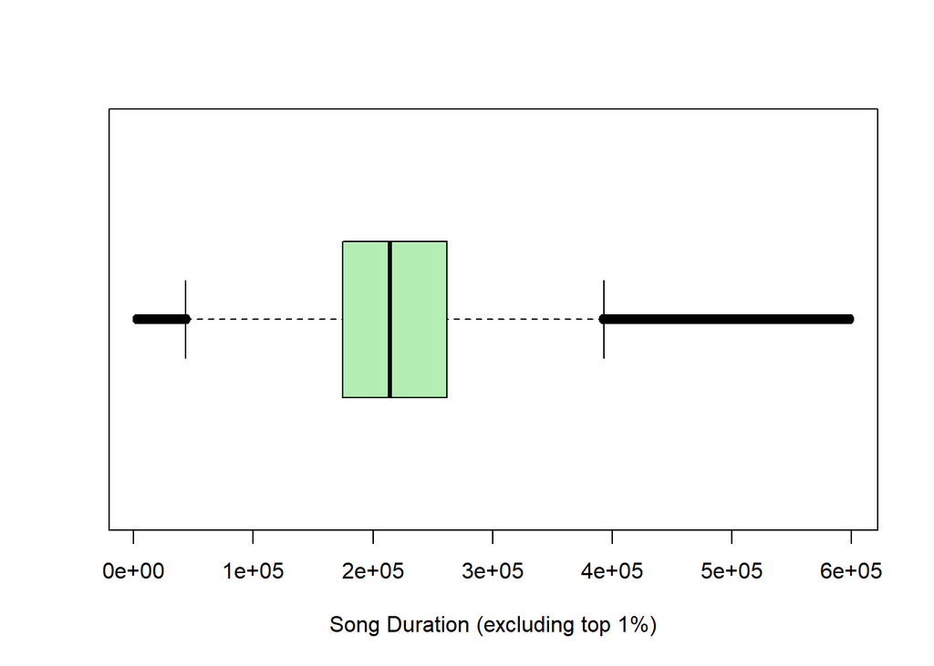

```r
audio_features$duration_ms <- ifelse(audio_features$duration_ms>598028, NA, audio_features$duration_ms) # Remove 1% longest-duration audio tracks (music longer than 10 minutes)
boxplot(audio_features$duration_ms, horizontal = T, col = "darkseagreen2", xlab = "Song Duration (excluding top 1%)")  # Verify that extreme outliers have been eliminated
```

```r
audio_features<-na.omit(audio_features)  #Remove 5867 rows from data set
```

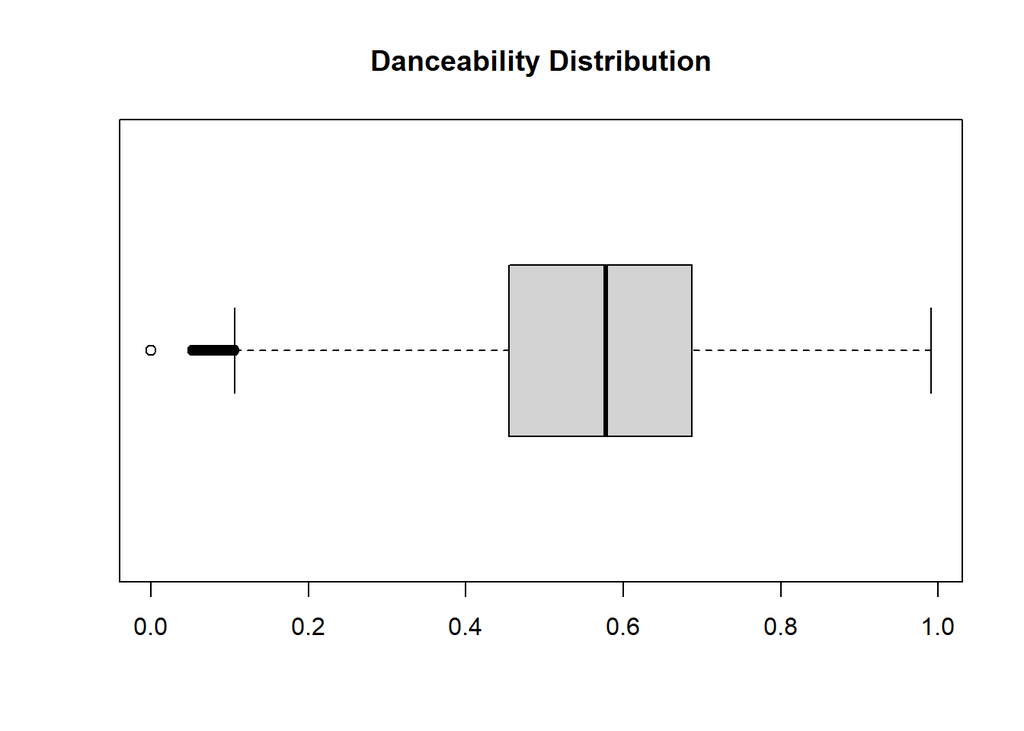

```r
#Look at danceability distribution in `audio_features`
boxplot(audio_features$danceability, horizontal=T, main="Danceability Distribution")
```

```r
quantile(audio_features$danceability, probs = c(.7,.71,.72,.75))   #Score of 6.7 falls at ~71st percentile
```

```
##   70%   71%   72%   75%
## 0.664 0.669 0.673 0.687
```

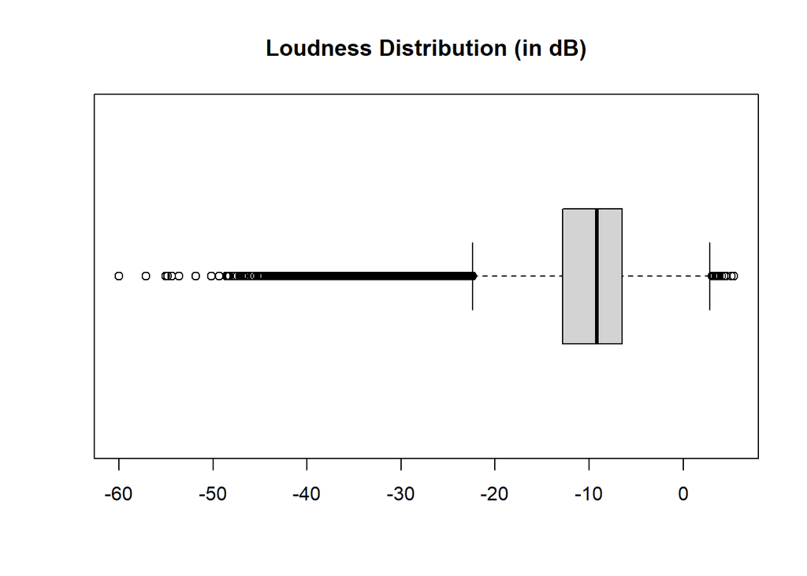

```r
boxplot(audio_features$loudness, horizontal=T, main="Loudness Distribution (in dB)")
```

```r
summary(audio_features$loudness)
```

```
##    Min. 1st Qu.  Median    Mean 3rd Qu.    Max.
## -60.000 -12.826  -9.205 -10.159  -6.461   5.376
```

### Train and Test

First we will parse the `audio_featuresN` into a train and test set. **Train & Test Sets for the Danceability Prediction**

```r
# All-numeric set
audio_featuresMM <- as.data.frame(model.matrix(~.-1,audio_features))  #all columns are numeric
#audio_featuresN<- lapply(audio_featuresMM,normalize) #apply normalize() to all columns
#audio_featuresN <- as.data.frame(audio_featuresN)  #This is a normalized set, if needed
test_set <- sample(1:nrow(audio_features), 30000)

#Train and Tests
audio_train <- audio_features[-test_set,]
audio_test <- audio_features[test_set,]
audio_trainMM <- audio_featuresMM[-test_set,]
audio_testMM <- audio_featuresMM[test_set,]

#Response Labels
audio_train_labs <- audio_features[-test_set,"danceability"]
audio_test_labs <- audio_features[test_set,"danceability"]
```

```r
boxplot(audio_features$duration_ms, horizontal=T)
boxplot(audio_featuresMM$duration_ms, horizontal=T)
boxplot(audio_train$duration_ms, horizontal=T)
boxplot(audio_train_shrunk$duration_ms, horizontal=T)
```

[output not shown]